# Отчет по лабораторной работе № 5

Расширенная настройка HTTP-сервера Apache

Бызова Мария Олеговна

## Цель работы

Целью данной работы является приобретение практических навыков по расширенному конфигурированию HTTP-сервера Apache в части безопасности и возможности использования PHP.

## Конфигурирование HTTP-сервера для работы через протокол HTTPS

На виртуальной машине server войдём под нашим пользователем и откроем терминал. Далее перейдём в режим суперпользователя. В каталоге /etc/ssl создадим каталог private (рис. 2)

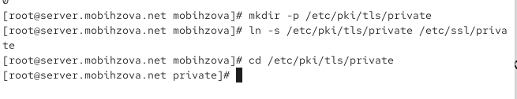

Рисунок 2: Переход в режим суперпользователя и создание в каталоге /etc/ssl каталога private.

## Конфигурирование HTTP-сервера для работы через протокол HTTPS

Сгенерируем ключ (рис. 3) и сертификат (рис. 4)

## Конфигурирование HTTP-сервера для работы через протокол HTTPS

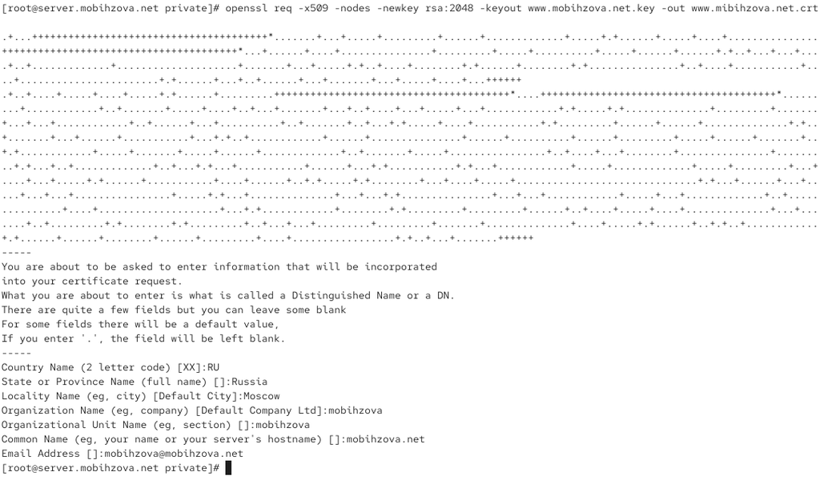

Рисунок 3: Генерация ключа.

## Конфигурирование HTTP-сервера для работы через протокол HTTPS

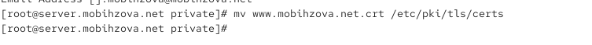

## Конфигурирование HTTP-сервера для работы через протокол HTTPS

Для перехода веб-сервера www.mobihzova.net на функционирование через протокол HTTPS требуется изменить его конфигурационный файл. Для этого перейдём в каталог с конфигурационными файлами (рис. 5)

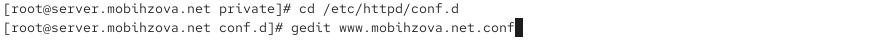

Рисунок 5: Открытие каталога с конфигурационными файлами.

## Конфигурирование HTTP-сервера для работы через протокол HTTPS

Откроем на редактирование файл /etc/httpd/conf.d/www.mobihzova.net.conf и заменим его содержимое на то, которое дано нам в лабораторной работе (рис. 6).

## Конфигурирование HTTP-сервера для работы через протокол HTTPS

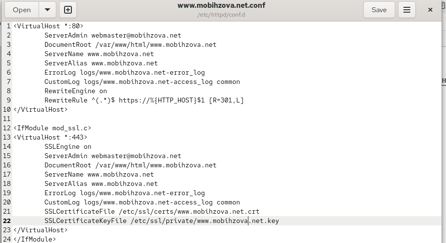

Рисунок 6: Открытие файла /etc/httpd/conf.d/www.mobihzova.net.conf на редактирование и замена содержимого.

## Конфигурирование HTTP-сервера для работы через протокол HTTPS

Внесём изменения в настройки межсетевого экрана на сервере, разрешив работу с https (рис. 7)

## Конфигурирование HTTP-сервера для работы через протокол HTTPS

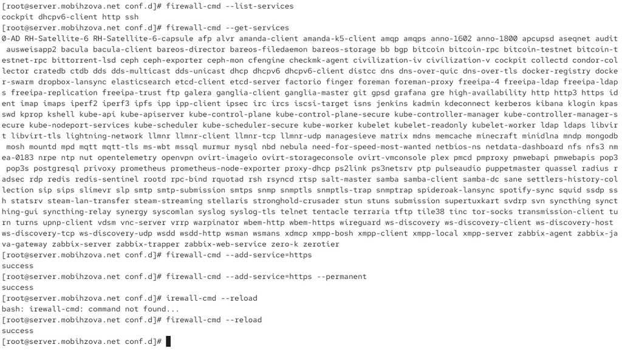

Рисунок 7: Внесение изменений в настройки межсетевого экрана на сервере, разрешив работу с https

## Конфигурирование HTTP-сервера для работы через протокол HTTPS

Перезапустим веб-сервер (рис. 8)

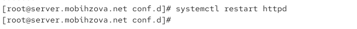

Рисунок 8: Перезапуск веб-сервера.

## Конфигурирование HTTP-сервера для работы через протокол HTTPS

На виртуальной машине client в строке браузера введём название веб- сервера www.mobihzova.net и убедимся, что произошло автоматическое переключение на работу по протоколу HTTPS. На открывшейся странице с сообщением о незащищённости соединения нажмём кнопку “Дополнительно”, затем добавим адрес нашего сервера в постоянные исключения. Затем просмотрим содержание сертификата. (рис. 9)

## Конфигурирование HTTP-сервера для работы через протокол HTTPS

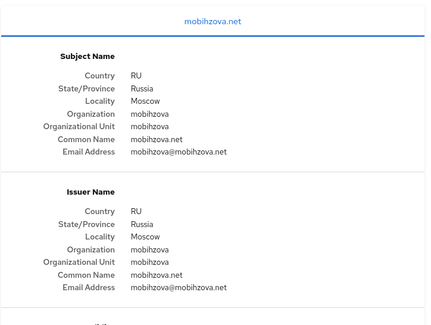

## Конфигурирование HTTP-сервера для работы с PHP

Установим пакеты для работы с PHP (рис. 10)

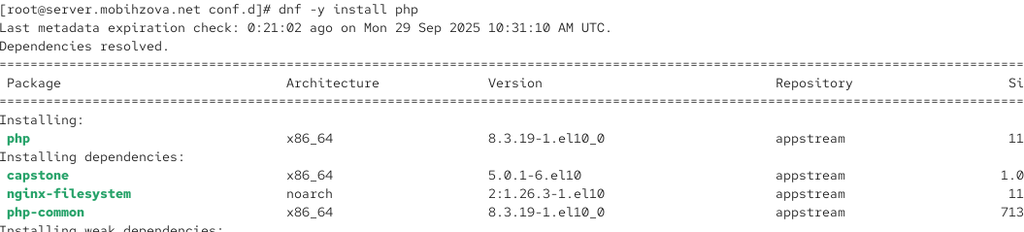

Рисунок 10: Установка пакетов для работы с PHP.

## Конфигурирование HTTP-сервера для работы с PHP

В каталоге /var/www/html/www.mobihzova.net заменим файл index.html на index.php следующего содержания (рис. 11)

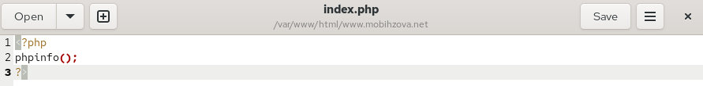

Рисунок 11: Замена файла index.html на index.php с содержанием из лабораторной работы.

## Конфигурирование HTTP-сервера для работы с PHP

Скорректируем права доступа в каталог с веб-контентом. После чего восстановим контекст безопасности в SELinux (рис. 12)

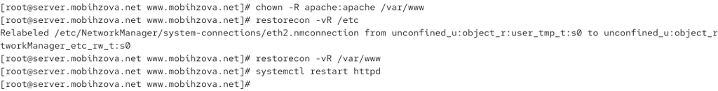

Рисунок 12: Корректировка прав доступа в каталог с веб-контентом, восстановление контекста безопасности в SELinux и перезапуск HTTP-сервера

## Конфигурирование HTTP-сервера для работы с PHP

На виртуальной машине client в строке браузера введём название веб-сервера www.mobihzova.net и убедимся, что будет выведена страница с информацией об используемой на веб-сервере версии PHP (рис. 13)

## Конфигурирование HTTP-сервера для работы с PHP

[figure not shown]

Рисунок 13: Проверка вывода страницы с информацией об используемой на веб-сервере версии PHP.

## Внесение изменений в настройки внутреннего окружения виртуальной машины

На виртуальной машине server перейдём в каталог для внесения изменений в настройки внутреннего окружения /vagrant/provision/server/http и в соответствующие каталоги скопируем конфигурационные файлы (рис. 14)

## Внесение изменений в настройки внутреннего окружения виртуальной машины

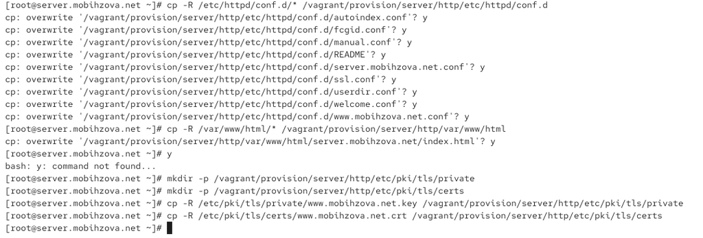

Рисунок 14: Внесение изменений в настройки внутреннего окружения /vagrant/provision/server/http и копирование конфигурационных файлов в каталоги.

## Внесение изменений в настройки внутреннего окружения виртуальной машины

В имеющийся скрипт /vagrant/provision/server/http.sh внесём изменения, добавив установку PHP и настройку межсетевого экрана, разрешающую работать с https (рис. 15).

## Внесение изменений в настройки внутреннего окружения виртуальной машины

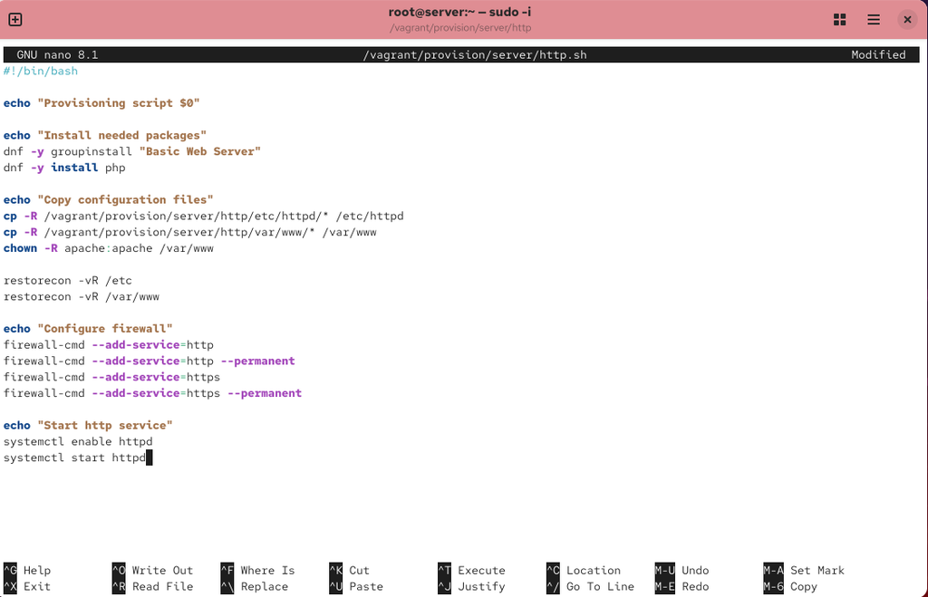

Рисунок 15: Внесение изменений в скрипт /vagrant/provision/server/http.sh, добавив установку PHP и настройку межсетевого экрана, разрешающую работать с https.

## Выводы

В ходе выполнения лабораторной работы были приобретены практические навыки по расширенному конфигурированию HTTP-сервера Apache в части безопасности и возможности использования PHP.